# PISA 2018 Dataset Exploration

## Preliminary Wrangling

- This notebook explores the PISA 2018 dataset found in this [link](http://www.oecd.org/pisa/data/2018database/)
- Dataset contains several questionnaires answered by 600k students 100k teachers and 22k schools
- Each student in this dataset also participates in a cognitive exam that may contain math, reading, science, and financial literacy questions.

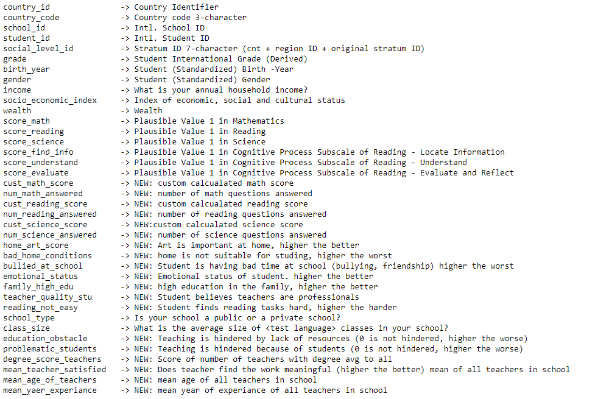

```python
Image(filename='./images/0.png')
```

- features used in this analysis

## Variable Exploration

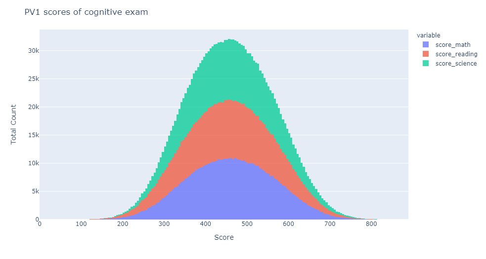

```python
Image(filename='./images/1.png')
```

- with a large enough sample size (600k) for each exam type we have a normal distribution
- bins used because of resource consumption (it lags with many interactive graphs)

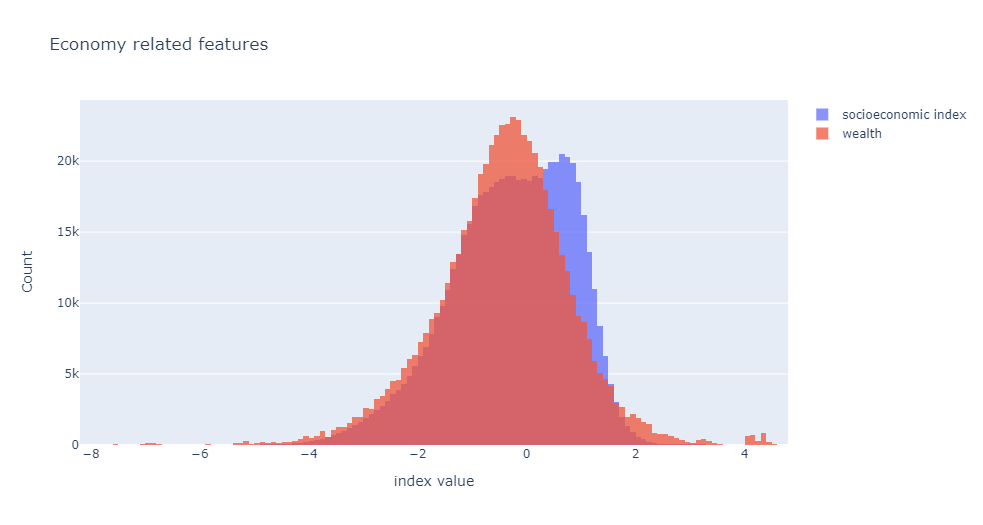

```python
Image(filename='./images/2.png')
```

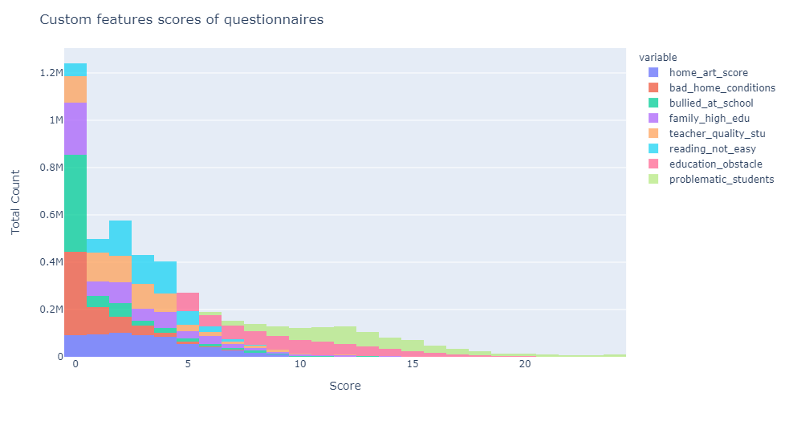

```python
Image(filename='./images/3.png')
```

- custom features focus on outliers. it is ok to have a skewed graph like this.
- seems like education obstacles (missing staff, equipment and material), and problematic students (teaching is hindered because of students) columns have a strong opinion by teachers

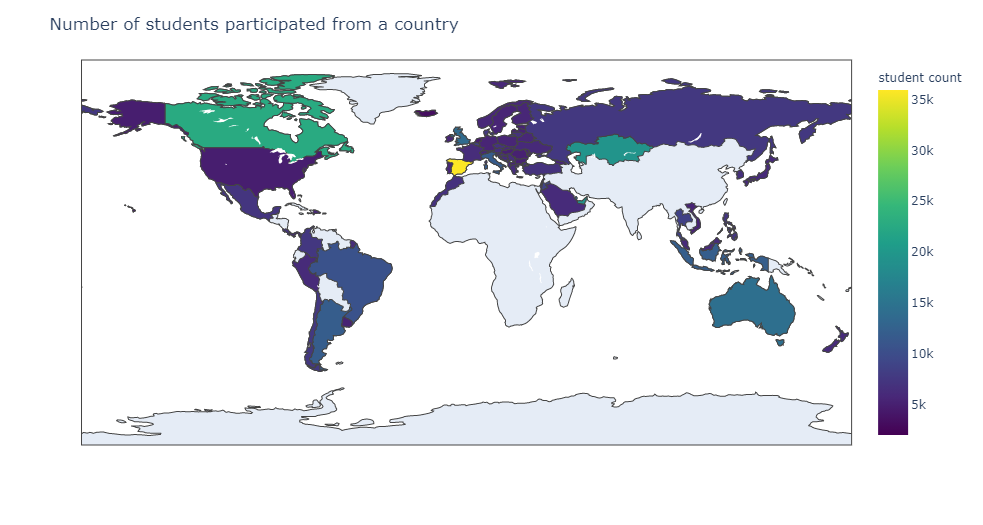

```python
Image(filename='./images/4.png')
```

- Canada, Spain and Kazakhstan participated the most
- there are quite a few countries in south east Asia
- Asia, Africa and some of the middle east is missing
- overall good representation of the population

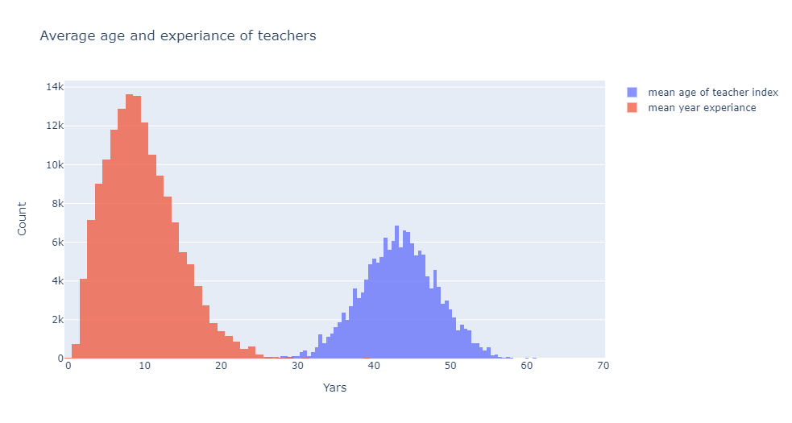

```python
Image(filename='./images/5.png')
```

- since the year is common and two values don't overlap much I decided to use both on the same chart
- average age of teachers is around 40-45
- most of them have been working as teacher 5+ years
- no outliers to be cleaned

## Bivariate Exploration

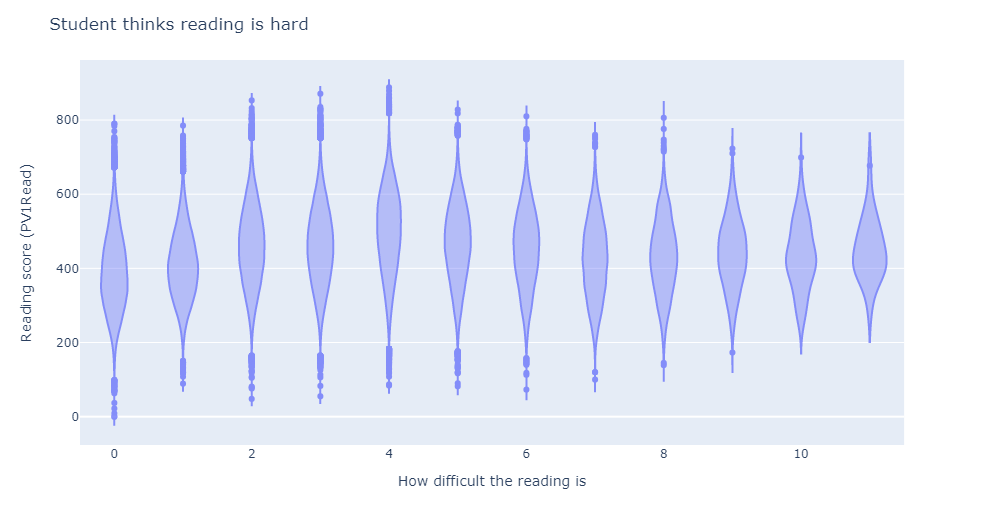

```python
Image(filename='./images/6.png')
```

- it seems students' understanding of difficulty is subjective.
- the more difficult reading is rated, the less we have outliers.
  - might mean they became aware of their strength and weaknesses if they rate something strongly
- however, ratings between 0-4 has quite a lot of students who received scores less than 200
  - maybe they didn't understand the questionnaire fully as well

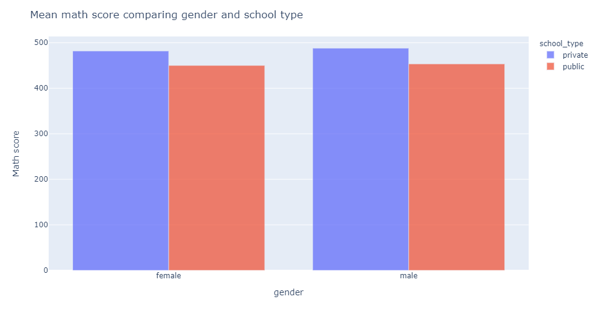

```python
Image(filename='./images/7.png')
```

- on average private schools score higher than public scores
- between genders average score is similar

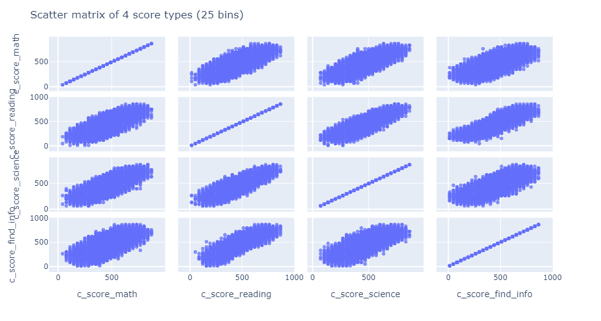

```python
Image(filename='./images/8.png')
```

- all scores seem to be positively correlated
- highest correlation seems to be with "reading" and "finding info from the text"

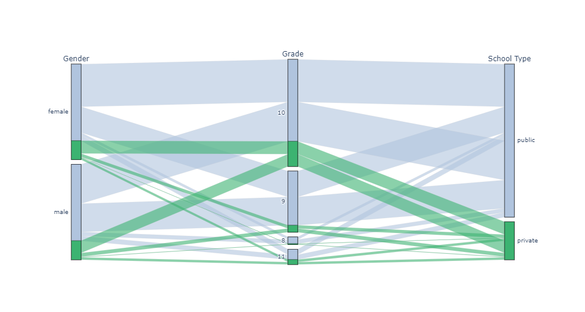

```python
Image(filename='./images/9.png')
```

- most private school participants in PISA is in 10th grade
- where the public school has similar distribution between 10th and 9th grade
- also there seems to be not a unified grade structure between countries (96,98)

## Multivariate Exploration

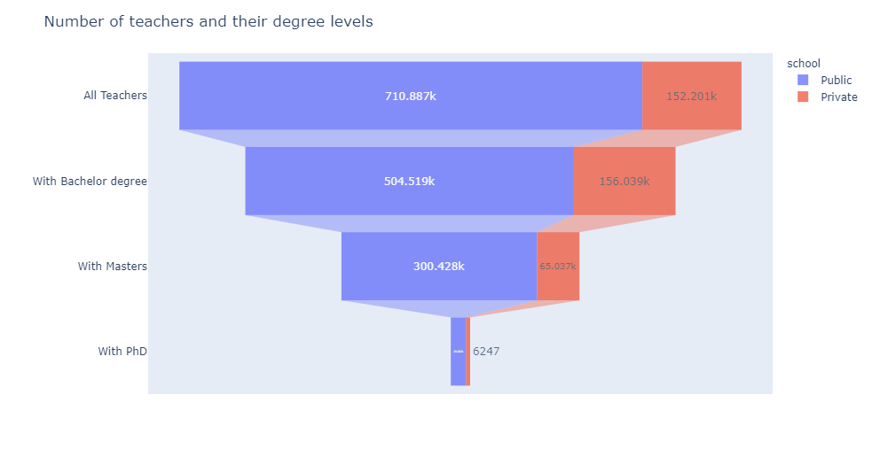

```python
Image(filename='./images/10.png')
```

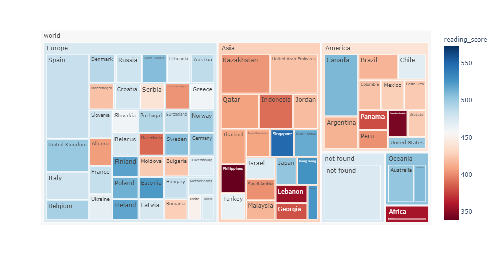

```python
Image(filename='./images/11.png')
```

- overall Europe doing better in reading compared to Asia and America
- Canada, Singapore, Japan, Albania, Macedonia -> these are some of the outliers in their continent
- size of the country show how many students took the exam

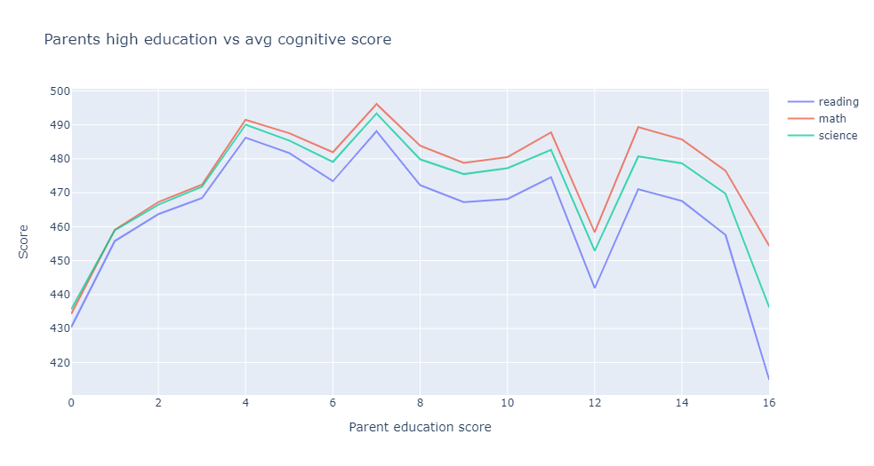

```python
Image(filename='./images/12.png')
```

- it looks like as the parents become more educated (masters degree) score increases
- however, mean score decreases after parents became Ph.D. owners